# Vaccine allocation project results

GMB

2022-06-01

# 1 Introduction

This document brings together results from multiple model runs. It is intended to be re-run as the model is updated.

NOTE: The setting for this run is: SLE

**Focus questions:**

- What impact will the existing vaccination plan have on morbidity and mortality?
- What impact can be achieved under different levels of vaccine coverage?
- What are the potential benefits of expanding the immunisation schedule to include children?

**Overarching assumptions**

Unless otherwise specified, key model parameters in this run are:

| Variable | Value | Source |
| --- | --- | --- |
| Circulating strain | omicron |  |
| Length of model run | 5 |  |
| Current vaccine coverage | dose one: 26%; dose two: 18% | John Hopkins COVID-19 vaccination data |
| Current vaccine coverage target | 51.6% | Government target in COVAX documentation May 2021 |
| Proportion of population willing to be vaccinated | 88% | Survey estimating vaccine acceptance in January 2021 (Solis et al., 2021) |
| Daily capacity for vaccination (doses) | 11075 | Slightly lower than the pilot vaccination campaign October-November 2021 |
| Anticipated type of future vaccine doses | Johnson & Johnson | The Government of Sierra Leone has demonstrated a strong preference for this vaccine, negotiating with major donors, such as the Government of Italy, to change their donations of double-dose vaccines … |
| Waning of VE against acquisition | TRUE |  |
| Waning of VE against severe disease | FALSE |  |
| Waning of infection-derived immunity against acquisition | TRUE |  |
| Waning of infection-derived immunity against severe outcomes | Not yet included |  |
| YLL discounting | 0 |  |

**Other assumptions/limitations:**

- Linear roll-out of vaccines (Lowy Institute report and trends in the ACT do not support this)
- Vaccine effectiveness estimates last updated on the 14th of April 2022 from WHO live systematic review (https://view-hub.org/covid-19/effectiveness-studies)

**Next steps for noting:**

- update of infection- and vaccine-derived immunity
- sensitivity analysis
  - turning on/off waning of vaccine-derived immunity
  - simulating outbreaks of different strains
  - experimenting with different age-prioritisation strategies
  - other?

# 2 Impact of current program targets

Roll out of current program target (51.6% coverage) during or prior to an outbreak:

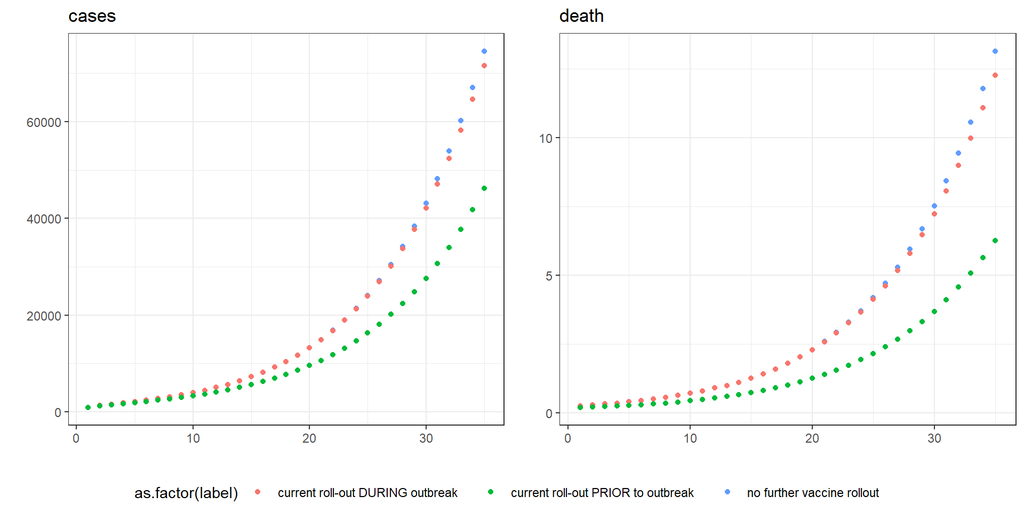

Absolute difference in outcomes (compared to no further vaccine roll-out)

| scenario | death | hosp | severe_disease | YLL | cases |
| --- | --- | --- | --- | --- | --- |
| current roll-out DURING outbreak | 4 | 257 | 69 | 55 | 13,070 |
| current roll-out PRIOR to outbreak | 58 | 4,221 | 1,002 | 844 | 225,981 |

Relative difference in outcomes

| scenario | death | hosp | severe_disease | YLL | cases |
| --- | --- | --- | --- | --- | --- |
| current roll-out DURING outbreak | 3.34 | 2.58 | 3.41 | 2.99 | 1.93 |
| current roll-out PRIOR to outbreak | 48.95 | 42.47 | 49.49 | 46.03 | 33.31 |

# 3 Varying levels of coverage

## 3.1 Using current age-specific eligiblity

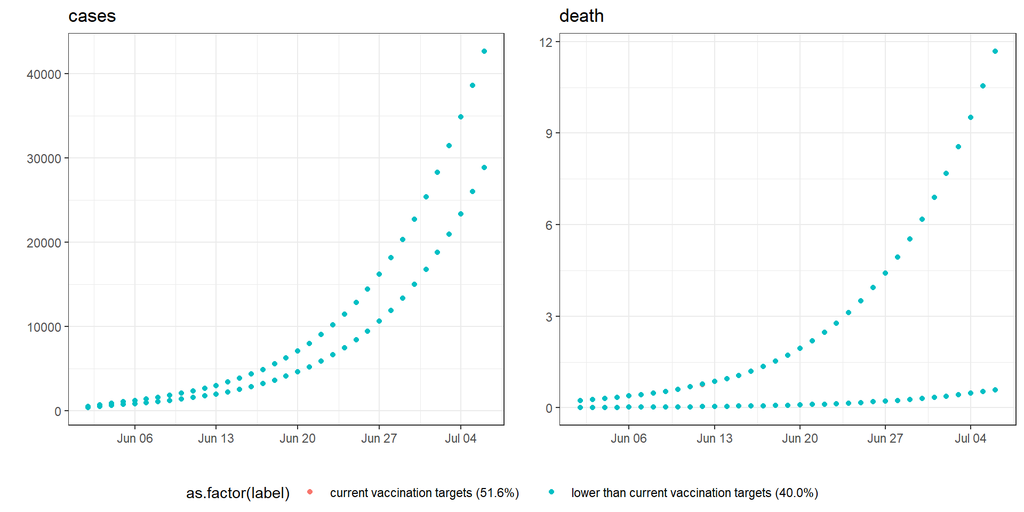

Absolute difference in outcomes (compared to current vaccine targets)

| scenario | macro_age_group | death | hosp | severe_disease | YLL | cases |
| --- | --- | --- | --- | --- | --- | --- |
| lower than current vaccination targets (40.0%) | adults | 0 | 0 | 0 | 0 | 0 |
| lower than current vaccination targets (40.0%) | children | 0 | 0 | 0 | 0 | 0 |
| lower than current vaccination targets (40.0%) | net | 0 | 0 | 0 | 0 | -1 |

Relative difference in outcomes (%)

| scenario | macro_age_group | death | hosp | severe_disease | YLL | cases |
| --- | --- | --- | --- | --- | --- | --- |
| lower than current vaccination targets (40.0%) | adults | 0 | 0 | 0 | 0 | 0 |
| lower than current vaccination targets (40.0%) | children | 0 | 0 | 0 | 0 | 0 |
| lower than current vaccination targets (40.0%) | net | 0 | 0 | 0 | 0 | 0 |

## 3.2 Expanding eligibility to children (DURING an outbreak)

### 3.2.1 Run current vaccine campaign, then expand to children

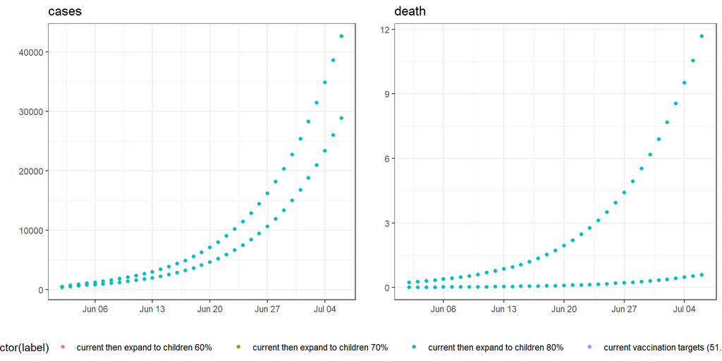

Absolute difference in outcomes (compared to current vaccine targets)

| scenario | macro_age_group | death | hosp | severe_disease | YLL | cases |
| --- | --- | --- | --- | --- | --- | --- |
| current then expand to children 60% | adults | 0 | 0 | 0 | 0 | 0 |
| current then expand to children 60% | children | 0 | 0 | 0 | 0 | 0 |
| current then expand to children 60% | net | 0 | 0 | 0 | 0 | -1 |
| current then expand to children 70% | adults | 0 | 0 | 0 | 0 | 0 |
| current then expand to children 70% | children | 0 | 0 | 0 | 0 | 0 |
| current then expand to children 70% | net | 0 | 0 | 0 | 0 | -1 |
| current then expand to children 80% | adults | 0 | 0 | 0 | 0 | 0 |
| current then expand to children 80% | children | 0 | 0 | 0 | 0 | 0 |
| current then expand to children 80% | net | 0 | 0 | 0 | 0 | -1 |

Relative difference in outcomes (%)

| scenario | macro_age_group | death | hosp | severe_disease | YLL | cases |
| --- | --- | --- | --- | --- | --- | --- |
| current then expand to children 60% | adults | 0 | 0 | 0 | 0 | 0 |
| current then expand to children 60% | children | 0 | 0 | 0 | 0 | 0 |
| current then expand to children 60% | net | 0 | 0 | 0 | 0 | 0 |
| current then expand to children 70% | adults | 0 | 0 | 0 | 0 | 0 |
| current then expand to children 70% | children | 0 | 0 | 0 | 0 | 0 |
| current then expand to children 70% | net | 0 | 0 | 0 | 0 | 0 |
| current then expand to children 80% | adults | 0 | 0 | 0 | 0 | 0 |
| current then expand to children 80% | children | 0 | 0 | 0 | 0 | 0 |
| current then expand to children 80% | net | 0 | 0 | 0 | 0 | 0 |

### 3.2.2 Expand to children now

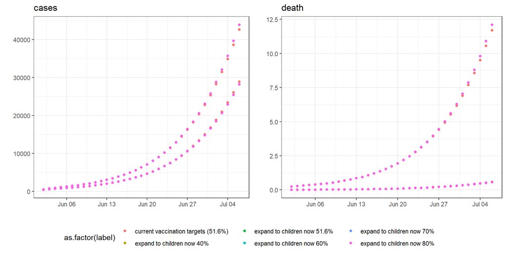

Absolute difference in outcomes (compared to current vaccine targets)

| scenario | macro_age_group | death | hosp | severe_disease | YLL | cases |
| --- | --- | --- | --- | --- | --- | --- |
| expand to children now 40% | adults | -2 | -122 | -36 | -27 | -5,722 |
| expand to children now 40% | children | 0 | 42 | 1 | 4 | 3,360 |
| expand to children now 40% | net | -2 | -81 | -35 | -23 | -2,362 |
| expand to children now 51.6% | adults | -2 | -122 | -36 | -27 | -5,722 |
| expand to children now 51.6% | children | 0 | 42 | 1 | 4 | 3,360 |
| expand to children now 51.6% | net | -2 | -81 | -35 | -23 | -2,362 |
| expand to children now 60% | adults | -2 | -122 | -36 | -27 | -5,722 |
| expand to children now 60% | children | 0 | 42 | 1 | 4 | 3,360 |
| expand to children now 60% | net | -2 | -81 | -35 | -23 | -2,362 |
| expand to children now 70% | adults | -2 | -122 | -36 | -27 | -5,722 |
| expand to children now 70% | children | 0 | 42 | 1 | 4 | 3,360 |
| expand to children now 70% | net | -2 | -81 | -35 | -23 | -2,362 |
| expand to children now 80% | adults | -2 | -122 | -36 | -27 | -5,722 |
| expand to children now 80% | children | 0 | 42 | 1 | 4 | 3,360 |
| expand to children now 80% | net | -2 | -81 | -35 | -23 | -2,362 |

Relative difference in outcomes (%)

| scenario | macro_age_group | death | hosp | severe_disease | YLL | cases |
| --- | --- | --- | --- | --- | --- | --- |
| expand to children now 40% | adults | -1.82 | -1.88 | -1.87 | -1.87 | -1.43 |
| expand to children now 40% | children | 1.25 | 1.31 | 1.49 | 1.19 | 1.26 |
| expand to children now 40% | net | -1.68 | -0.83 | -1.78 | -1.30 | -0.36 |
| expand to children now 51.6% | adults | -1.82 | -1.88 | -1.87 | -1.87 | -1.43 |
| expand to children now 51.6% | children | 1.25 | 1.31 | 1.49 | 1.19 | 1.26 |
| expand to children now 51.6% | net | -1.68 | -0.83 | -1.78 | -1.30 | -0.36 |
| expand to children now 60% | adults | -1.82 | -1.88 | -1.87 | -1.87 | -1.43 |
| expand to children now 60% | children | 1.25 | 1.31 | 1.49 | 1.19 | 1.26 |
| expand to children now 60% | net | -1.68 | -0.83 | -1.78 | -1.30 | -0.36 |
| expand to children now 70% | adults | -1.82 | -1.88 | -1.87 | -1.87 | -1.43 |
| expand to children now 70% | children | 1.25 | 1.31 | 1.49 | 1.19 | 1.26 |
| expand to children now 70% | net | -1.68 | -0.83 | -1.78 | -1.30 | -0.36 |
| expand to children now 80% | adults | -1.82 | -1.88 | -1.87 | -1.87 | -1.43 |
| expand to children now 80% | children | 1.25 | 1.31 | 1.49 | 1.19 | 1.26 |
| expand to children now 80% | net | -1.68 | -0.83 | -1.78 | -1.30 | -0.36 |

## 3.3 Expanding eligibility to children (PRIOR TO an outbreak)

Note: If waning immunity against severe outcomes ON, this looks like a bad idea.

### 3.3.1 Run current vaccine campaign, then expand to children

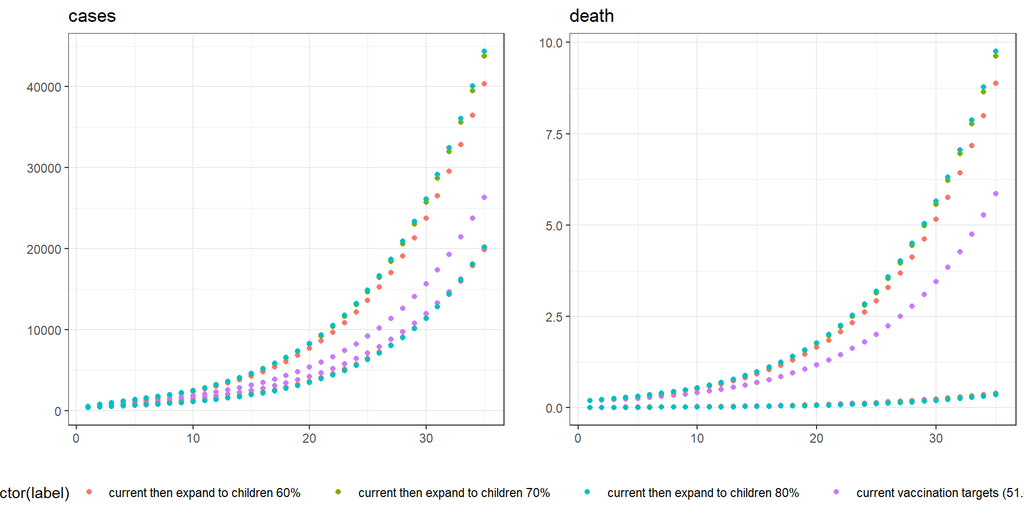

Absolute difference in outcomes (compared to current vaccine targets)

| scenario | macro_age_group | death | hosp | severe_disease | YLL | cases |
| --- | --- | --- | --- | --- | --- | --- |
| current then expand to children 60% | adults | -26 | -1,676 | -485 | -361 | -123,197 |
| current then expand to children 60% | children | 0 | 246 | 5 | 19 | 13,781 |
| current then expand to children 60% | net | -26 | -1,430 | -480 | -342 | -109,416 |
| current then expand to children 70% | adults | -32 | -2,080 | -602 | -449 | -152,706 |
| current then expand to children 70% | children | 1 | 429 | 8 | 35 | 15,710 |
| current then expand to children 70% | net | -31 | -1,652 | -594 | -413 | -136,995 |
| current then expand to children 80% | adults | -33 | -2,156 | -624 | -465 | -158,217 |
| current then expand to children 80% | children | 1 | 534 | 10 | 45 | 16,367 |
| current then expand to children 80% | net | -32 | -1,622 | -614 | -420 | -141,850 |

Relative difference in outcomes (%)

| scenario | macro_age_group | death | hosp | severe_disease | YLL | cases |
| --- | --- | --- | --- | --- | --- | --- |
| current then expand to children 60% | adults | -45.59 | -49.82 | -49.07 | -48.41 | -48.21 |
| current then expand to children 60% | children | 9.06 | 10.47 | 14.25 | 7.81 | 7.00 |
| current then expand to children 60% | net | -42.00 | -25.01 | -46.89 | -34.61 | -24.18 |
| current then expand to children 70% | adults | -56.57 | -61.84 | -60.92 | -60.10 | -59.76 |
| current then expand to children 70% | children | 16.28 | 18.23 | 23.47 | 14.53 | 7.97 |
| current then expand to children 70% | net | -51.78 | -28.89 | -58.02 | -41.78 | -30.27 |
| current then expand to children 80% | adults | -58.60 | -64.09 | -63.14 | -62.29 | -61.92 |
| current then expand to children 80% | children | 20.53 | 22.70 | 28.52 | 18.59 | 8.31 |
| current then expand to children 80% | net | -53.41 | -28.38 | -59.99 | -42.43 | -31.35 |

### 3.3.2 Expand to children now

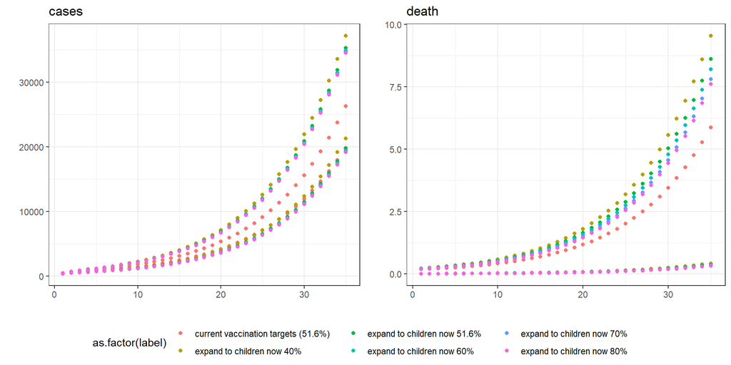

Absolute difference in outcomes (compared to current vaccine targets)

| scenario | macro_age_group | death | hosp | severe_disease | YLL | cases |
| --- | --- | --- | --- | --- | --- | --- |
| expand to children now 40% | adults | -33 | -2,039 | -594 | -448 | -96,145 |
| expand to children now 40% | children | 0 | 22 | 1 | -2 | -2,663 |
| expand to children now 40% | net | -33 | -2,017 | -592 | -450 | -98,808 |
| expand to children now 51.6% | adults | -25 | -1,552 | -450 | -338 | -80,025 |
| expand to children now 51.6% | children | 0 | 290 | 5 | 25 | 11,475 |
| expand to children now 51.6% | net | -24 | -1,262 | -445 | -314 | -68,550 |
| expand to children now 60% | adults | -21 | -1,331 | -385 | -289 | -76,073 |
| expand to children now 60% | children | 1 | 407 | 7 | 36 | 14,629 |
| expand to children now 60% | net | -20 | -924 | -378 | -252 | -61,444 |
| expand to children now 70% | adults | -17 | -1,108 | -320 | -239 | -73,797 |
| expand to children now 70% | children | 1 | 524 | 9 | 47 | 16,232 |
| expand to children now 70% | net | -16 | -584 | -311 | -191 | -57,565 |
| expand to children now 80% | adults | -15 | -991 | -286 | -212 | -72,865 |
| expand to children now 80% | children | 1 | 584 | 10 | 53 | 16,836 |
| expand to children now 80% | net | -14 | -407 | -276 | -159 | -56,029 |

Relative difference in outcomes (%)

| scenario | macro_age_group | death | hosp | severe_disease | YLL | cases |
| --- | --- | --- | --- | --- | --- | --- |
| expand to children now 40% | adults | -58.04 | -60.61 | -60.08 | -60.08 | -37.63 |
| expand to children now 40% | children | 0.03 | 0.92 | 3.30 | -0.76 | -1.35 |
| expand to children now 40% | net | -54.23 | -35.29 | -57.90 | -45.52 | -21.83 |
| expand to children now 51.6% | adults | -43.27 | -46.13 | -45.58 | -45.34 | -31.32 |
| expand to children now 51.6% | children | 11.21 | 12.34 | 15.36 | 10.20 | 5.82 |
| expand to children now 51.6% | net | -39.69 | -22.08 | -43.49 | -31.71 | -15.15 |
| expand to children now 60% | adults | -36.65 | -39.56 | -39.01 | -38.67 | -29.77 |
| expand to children now 60% | children | 16.04 | 17.32 | 20.73 | 14.90 | 7.43 |
| expand to children now 60% | net | -33.19 | -16.16 | -36.96 | -25.52 | -13.58 |
| expand to children now 70% | adults | -30.02 | -32.93 | -32.40 | -31.97 | -28.88 |
| expand to children now 70% | children | 20.82 | 22.26 | 26.12 | 19.54 | 8.24 |
| expand to children now 70% | net | -26.68 | -10.22 | -30.39 | -19.32 | -12.72 |
| expand to children now 80% | adults | -26.56 | -29.47 | -28.95 | -28.47 | -28.52 |
| expand to children now 80% | children | 23.31 | 24.84 | 28.94 | 21.94 | 8.55 |
| expand to children now 80% | net | -23.29 | -7.12 | -26.96 | -16.09 | -12.38 |

# 4 Varying speed of vaccine roll-out

This section models varying speeds of vaccine roll-out *DURING* an outbreak.

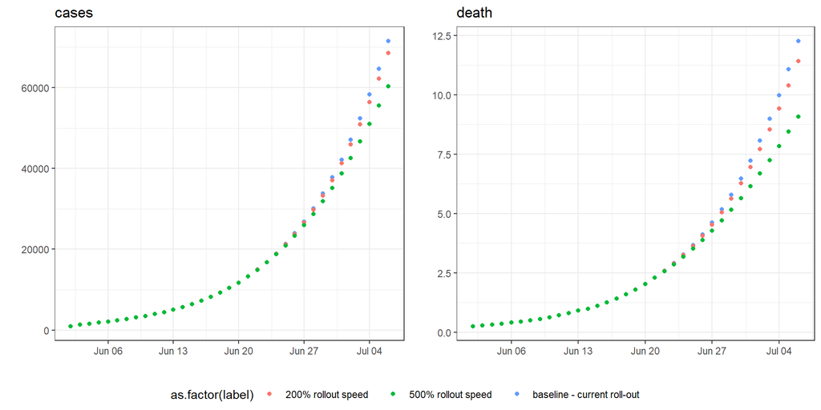

Absolute difference in outcomes (compared to current rollout speed)

| scenario | death | hosp | severe_disease | YLL | cases |
| --- | --- | --- | --- | --- | --- |
| 200% rollout speed | 4 | 250 | 67 | 54 | 12,772 |
| 500% rollout speed | 15 | 966 | 260 | 207 | 49,373 |

Relative difference in outcomes (%)

| scenario | death | hosp | severe_disease | YLL | cases |
| --- | --- | --- | --- | --- | --- |
| 200% rollout speed | 3.38 | 2.59 | 3.44 | 3.01 | 1.92 |
| 500% rollout speed | 13.04 | 9.98 | 13.27 | 11.62 | 7.42 |